# Finding and Fixing Vulnerabilities Using AI – Identify findings

## 5.1 Identify findings

Let’s discuss how to identify possible vulnerabilities (aka “findings”) once we’re prepared to do it.

As we noted earlier, simply pointing a generic AI coding agent at an arbitrary software repository and asking it to discover vulnerabilities *can* work, in the sense that it may find a vulnerability [[Bourzikas2026](https://blog.cloudflare.com/cyber-frontier-models/)]. That’s *especially* true if the software hasn’t been previously examined by AI and/or if the AI model is especially good at program analysis.

*However*, this trivial approach often doesn’t provide meaningful coverage of real codebases of significant size, nor does it necessarily identify valuable findings. AI can be very effective at finding vulnerabilities [[Rogers2025](https://joshua.hu/llm-engineer-review-sast-security-ai-tools-pentesters)]. However, if you want to do a *good* job at finding and fixing vulnerabilities using AI, you generally want to have some kind of harness around the AI to help it focus. Some of the reasons for this need, especially for less-capable models, are:

- Context: A single agent’s context window will easily fill if it tries to do too much at once. Even if it doesn’t technically fill up, an AI agent often struggles when it has too much irrelevant information at once. It’s better to narrowly focus on a specific issue and do that repeatedly.
- Throughput: Instead of running a single agent hard, it’s better to fan them out in parallel. Otherwise, it takes a long time to produce results, and it won’t adequately examine each potential issue in enough depth [[Bourzikas2026](https://blog.cloudflare.com/cyber-frontier-models/)].

In short, coverage is better when “many agents work on tightly scoped questions and we deduplicate the results afterward, rather than asking one agent to be exhaustive.” [[Bourzikas2026](https://blog.cloudflare.com/cyber-frontier-models/)]

### 5.1.1 Separate identifying findings from validation

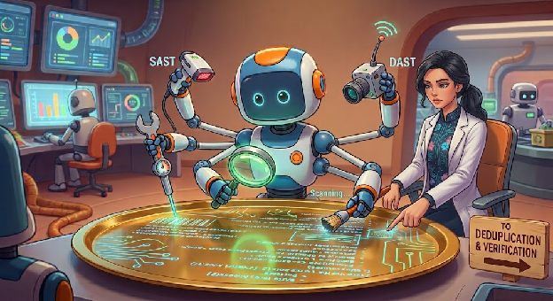

A robot and human are working together to analyze a disk representing software, before their results go to deduplication and verification.

One excellent way to improve results is to separate *identifying* findings from *validating* findings. A “finding” is simply a construct that *might* be a vulnerability, but is not necessarily a vulnerability because it’s not clear if it’s exploitable.

Splitting up identifying findings from validating them makes finding vulnerabilities more likely:

- As [[Bourzikas2026](https://blog.cloudflare.com/cyber-frontier-models/)] notes, “asking ‘Is this code buggy?’ and ‘Can an attacker actually reach this bug from outside the system?’ are two different questions, and the model is better at each one when you ask them separately, because each question is narrower than the combined version.”
- As [[Yan2026](https://claude.com/blog/using-llms-to-secure-source-code)] reports, “In other words, discovery should find as many vulnerabilities as possible—even unlikely ones—and verification should exclude findings that are not actually exploitable. When an agent tries to do both in the same step, it can self censor and exclude exploitable true positives. We learned this the hard way, where asking discovery agents to also verify findings led to them filtering out true positives that a separate verification step would have confirmed.”

So we’ll first focus on identifying findings, and we’ll later discuss validating findings.

### 5.1.2 Helping to identify findings

It’s best to help the AI identify findings. There are many ways to help identify findings when using AI:

1. *In general, give the AI tools*. That includes tools to search and read the code, security tools, and so on. Consider asking the AI what tools it might need and make them available [[Yan2026](https://claude.com/blog/using-llms-to-secure-source-code)]. Provide the AI basic tools (e.g., scripting languages like Python) so it can write its own tools to aid in finding (just like a human might do).
2. *In particular, use traditional non-AI tools that search for potential vulnerabilities*. These include various static analysis tools (examining the source code or binary) and dynamic analysis tools (including fuzzers and web application scanners). Integrating these traditional tools with AI can be powerful. “Agentic AI is already beginning to help scale vulnerability discovery by leveraging traditional tooling.” [Rohlf2025].
3. *Prioritize code that’s especially concerning*. One list suggests code that parses untrusted input, enforces authentication or authorization, or is reachable from the internet [Cycode2026, quoting Anthropic]. The Mozilla Firefox project reports that their “scanning is largely focused on specific areas of the code (files, functions) where we instruct the system to look, based on a mix of human judgement and automated signals.” [[Grinstead2026-05](https://hacks.mozilla.org/2026/05/behind-the-scenes-hardening-firefox/)]
4. *To find security vulnerabilities include a search for language-specific issues, insecure coding practices, and improper handling of parameters, variables, and data flows*. For each programming language used in the project, apply checks for language- and framework-specific vulnerabilities. Trace parameters, variables, and their usage throughout the code to detect unsafe patterns, misuse, or inconsistencies [[Rogers2025](https://joshua.hu/llm-engineer-review-sast-security-ai-tools-pentesters)].
5. *Have the model examine and cluster past bugs or at least past vulnerabilities*. For vulnerabilities (as determined by your threat model), have it list the relevant vulnerability classes. Then have the AI system determine (for every fix) if the fix was complete and if it applied everywhere else. Look for similar problems. [[Yan2026](https://claude.com/blog/using-llms-to-secure-source-code)] reported that one team did this and found three exploitable issues in an hour, saying “’What have people exploited in the past’ is sometimes a much easier cheat-code towards success than ‘find me vulnerabilities in this codebase.’”
6. *Use “top” lists of the most likely kinds of vulnerabilities*. At *least* look specifically for common vulnerabilities. “Most software security issues discovered each year are simply variants or instances of previously discovered patterns, rather than entirely new classes of vulnerabilities.” [Rohlf2025] So if the produced system is…
   1. a web application, use the OWASP Top 10 vulnerabilities (for web applications) https://owasp.org/www-project-top-ten/
   2. agentic, use the OWASP Top 10 for Agentic Applications for 2026 https://genai.owasp.org/resource/owasp-top-10-for-agentic-applications-for-2026/
   3. Anything else (including internet of things (IoT)), use the CWE Top 25.
7. *Look for cases where a component presumes another component does something but there’s no test verifying it*. “Many vulnerabilities are being found ‘in the seams’ between programs, e.g., a library might not filter headers, even if its spec requires header filtering, but all of the library users might expect the library to filter headers.” [Zimmer2026]
8. *Include important non-security bugs, focusing on critical issues that are likely to cause application crashes, severe malfunctions, or significant instability*. Minor or cosmetic issues are less risky, but important “non-security” defects can often be exploited as vulnerabilities. [[Rogers2025](https://joshua.hu/llm-engineer-review-sast-security-ai-tools-pentesters)] claims that “the greatest success I had with policies was a really simply policy of `find all bugs, even if they’re not vulnerabilities’” Consider as a bug cases where the claimed intent (in some documentation including comments) disagrees with the actual code as written. These can be important to fix anyway, and while the system may initially *believe* they aren’t security-related, they may turn out to be vulnerabilities anyway.
9. *Consider disabling some hardening mechanisms that are used in production when finding (and also when later validating)*. This way, the hardening mechanisms are truly an additional defense-in-depth measure. The result is that the full system that includes its hardening mechanisms is much harder for an adversary to successfully attack. [[Grinstead2026-05](https://hacks.mozilla.org/2026/05/behind-the-scenes-hardening-firefox/)]
10. *Include information on configuration, dependencies, deployment choices, and how components are combined*. “Many exploitable issues do no appear as obvious defects in application source code” but instead emerge from these kinds of problems [[Ziegler2026](https://xbow.com/blog/mythos-offensive-security-xbow-evaluation)].

Focus on specific files or specific functions for a given analysis. Many first use AI to identify the “most important” files and functions to examine, then examine those first.

At the time of this writing, it’s not clear what level of prescription is appropriate. [[Yan2026](https://claude.com/blog/using-llms-to-secure-source-code)] claims that with frontier models, more prescriptive prompts (such as long checklists) make discovery worse, as they “tend to reduce the model’s creativity and generate fewer novel bugs”. Others don’t report the same. No matter what, all agree that providing data on what counts as a threat model and providing tools is vital.

When asking for findings, include a definition of what output format and content you want. Ask for a structured report with predefined fields, and order them so the model’s reasoning builds on each field. Example fields include rationale, finding, impact, severity, etc. [[Yan2026](https://claude.com/blog/using-llms-to-secure-source-code)]. Ask for very detailed information about each finding including a detailed description, filenames, line#s, the specific triggering input and configuration, relevant URLs, and anything else that would help an AI or human validate it later [[Rogers2025](https://joshua.hu/llm-engineer-review-sast-security-ai-tools-pentesters)]. Ask for a proof of concept (PoC) if it can provide it, but be clear that a PoC is not *required* and findings should be reported even if it cannot create a PoC. A PoC can simplify later validation if it can be created, but we don’t want to pre-filter findings too early.

Where practical, include provenance needed to reproduce and interpret the result. This can include the source revision examined, relevant environment and configuration, the analysis or verifier invocation that produced the evidence, and the threat-model assumptions used when evaluating the finding. Provenance makes it easier to reproduce a result, determine whether it still applies after the software changes, and distinguish observed evidence from an AI-generated explanation [[SARIF2.1](https://docs.oasis-open.org/sarif/sarif/v2.1.0/os/sarif-v2.1.0-os.html)].

### 5.1.3 Findings process

Apply a findings process, and don’t let yourself or the AI get overwhelmed or confused.

Remember, *not* all findings are actual vulnerabilities, and that’s okay. Unfortunately, finding counts can sometimes mislead others. As [[Ottenheimer2026-05-26](https://www.flyingpenguin.com/mythos-grading-mythos-got-patches-yet/)] “Glasswing is NOT confidently reporting tens of thousands of real bugs…, like any tool, they are reporting tens of thousands of findings, of which a confident count of real bugs is much smaller.” That doesn’t mean AI is useless, far from it. It’s just that findings need to be validated after they’re found. Repeatedly make it clear that a finding is *not* a confirmed vulnerability, it’s a *possible* vulnerability.

Don’t assume that all findings were found when AI completes some run. As we noted earlier, modern AI systems are generally non-deterministic [[Rogers2025](https://joshua.hu/llm-engineer-review-sast-security-ai-tools-pentesters)]. Re-running may produce some more findings even if all of a previous run’s findings were examined. In addition, discovering potential vulnerabilities (and validating them later) can be a challenge, since this process is related to mathematically undecidable problems in computer science [Rohlf2025]. If done well, this should be a case of diminishing returns. The best way to see how quickly the number of findings are diminishing is to keep re-run finding efforts until the process increasingly comes up empty-handed.

Also, distinguish a successful analysis that produced no findings from an analysis that did not successfully complete. A timeout, model or tool failure, environment failure, insufficient permission, policy denial, or similar interruption is not evidence that no vulnerabilities were found. Automated workflows should record these outcomes separately so that an incomplete analysis cannot silently become a “no findings” result [[SARIF2.1](https://docs.oasis-open.org/sarif/sarif/v2.1.0/os/sarif-v2.1.0-os.html)].

**Quiz**

Q1. According to the guide, why is it better to separate the task of identifying findings from the task of validating findings, rather than asking one AI agent to do both at once?

1. Because an agent’s context window would typically fill up trying to hold both tasks at once, even though combining them would otherwise maximize its results.
2. Because this avoids stopping analysis too soon, since a combined agent may filter out true positives too early that a separate verifier would confirm.
3. Because separating the two tasks makes it easier to fan agents out in parallel for throughput, which is the main reason results improve.
4. Because AI guardrails block an agent from producing a working proof of concept, so a second, unrestricted agent must always be applied to verify it separately from finding.

**Show answer**

Answer: B

**Quiz**

Q1. The guide recommends using different “top” vulnerability lists depending on what kind of system you’re examining. Which list does it recommend for a general system that’s neither a web application nor an agentic application, such as an IoT device?

1. OWASP Top 10 (for web applications)
2. OWASP Top 10 for Agentic Applications
3. CWE Top 25
4. NIST SP 800-53 control catalog

**Show answer**

Answer: C